# EDA Assignment 4

# For Salaries in SF

We are going to reexpress the variable Total.benefits to be symmetric.

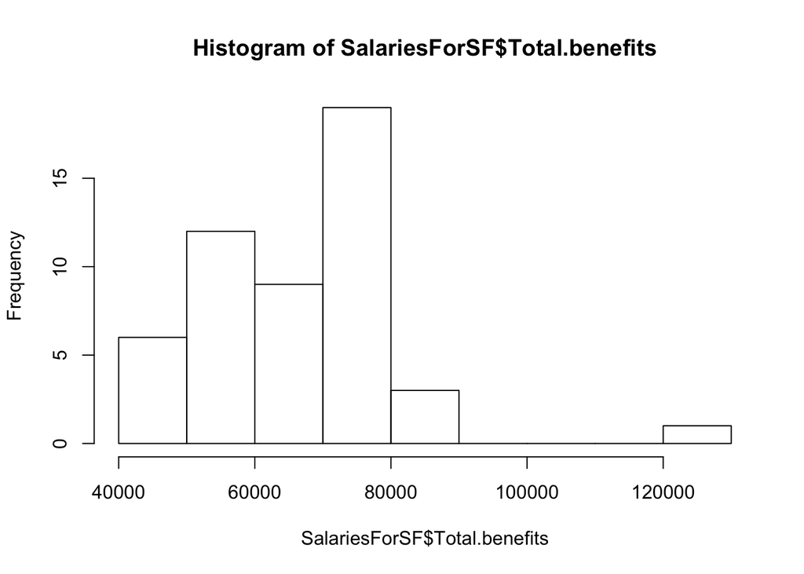

```r
SalariesForSF <- read.csv("https://docs.google.com/spreadsheets/d/1tqh_FERElW3C0Z_Rn2NP76SZdsbKsrViqjw_vtQEFww/pub?output=csv")
hist(SalariesForSF$Total.benefits)
```

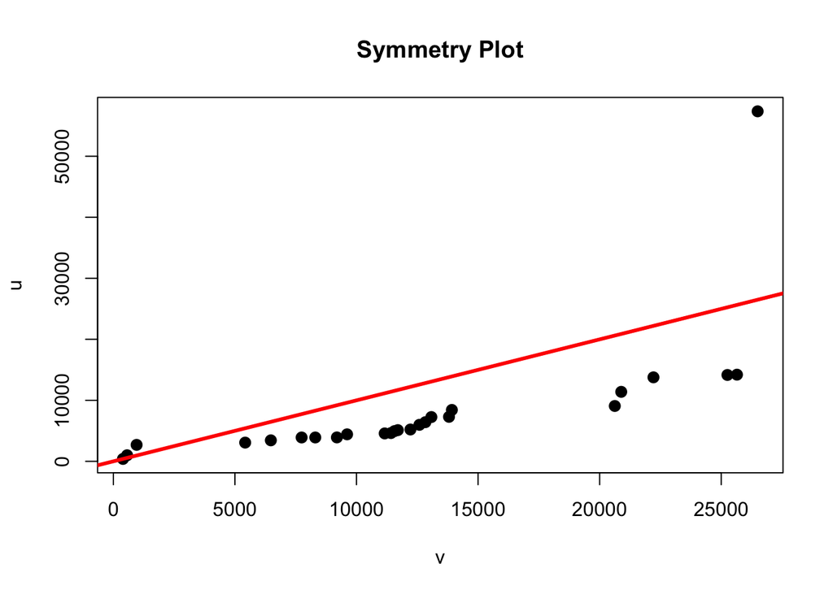

```r
symplot(SalariesForSF$Total.benefits)
```

There is slightly left-skewedness in the symplot since the points fall under the red rine. There is one outlier in the tail.

```r
letter.values <- lval(SalariesForSF$Total.benefits)
letter.values$mids
```

```
## [1] 68528.65 65235.42 65778.85 64305.05 62892.05 83961.10
```

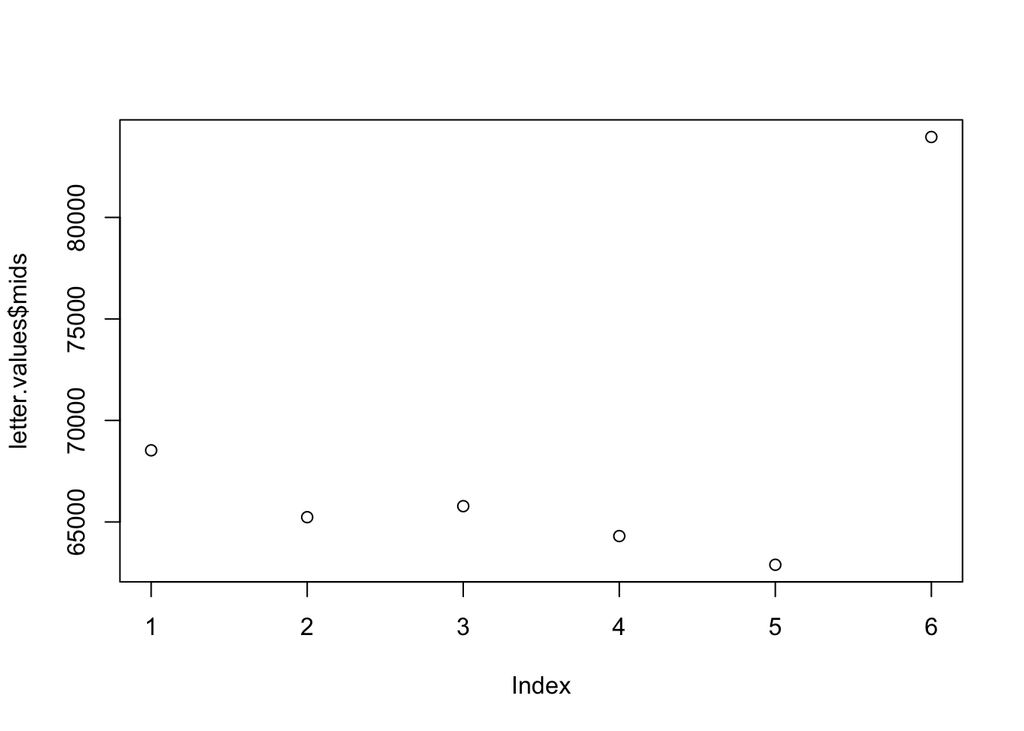

```r
plot(letter.values$mids)
```

You can see the left skewness since this sequence is in decreasing. However, in the tail you can see that the value jumps.

```r
#take roots
roots <- sqrt(SalariesForSF$Total.benefits)
aplpack::stem.leaf(roots)
```

```
## 1 | 2: represents 12
##  leaf unit: 1
##             n: 50
##    3    20 | 578
##    6    21 | 588
##         22 |
##   16    23 | 3355678889
##   21    24 | 23569
##   (2)   25 | 19
##   27    26 | 0123678999
##   17    27 | 000111235578
##    5    28 | 2677
## HI: 354.812246124623
```

```r
root.lv <- lval(roots)
root.lv
```

```
##   depth       lo       hi     mids   spreads
## M  25.5 261.7787 261.7787 261.7787   0.00000
## H  13.0 238.3884 271.3703 254.8793  32.98190
## E   7.0 233.6802 277.4009 255.5405  43.72075
## D   4.0 215.2096 286.8709 251.0403  71.66137
## C   2.5 207.5488 287.5889 247.5688  80.04017
## B   1.0 205.0134 354.8122 279.9128 149.79888
```

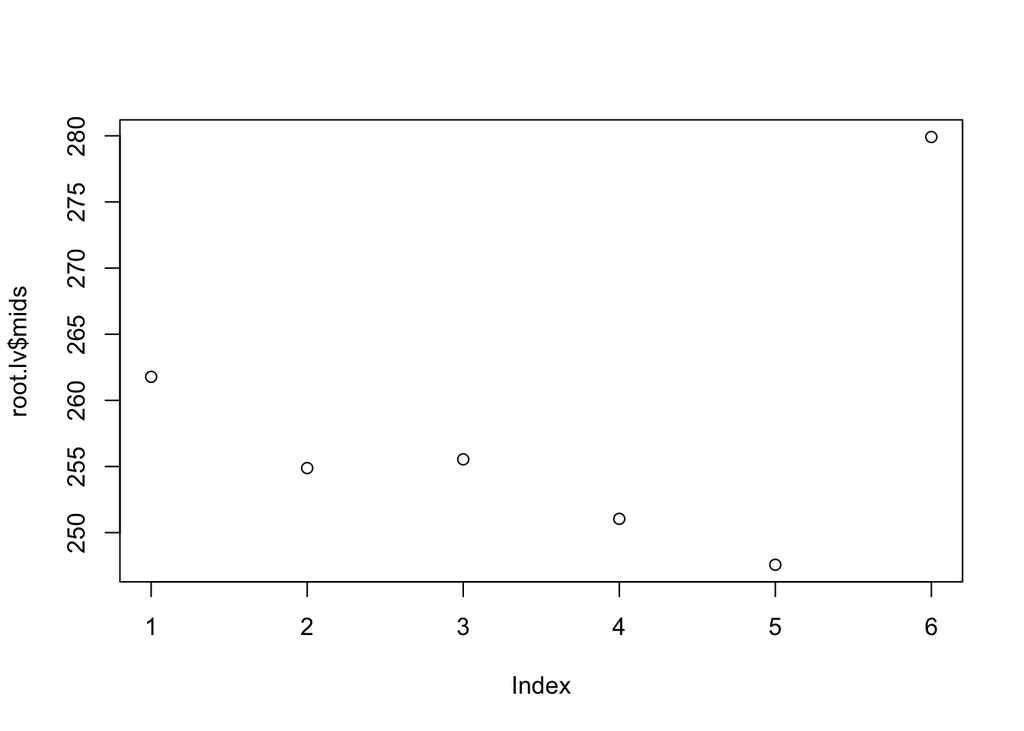

```r
plot(root.lv$mids)
```

```r
#take log
logs <- log(SalariesForSF$Total.benefits)
aplpack::stem.leaf(logs)
```

```
## 1 | 2: represents 0.12
##  leaf unit: 0.01
##             n: 50
##    1    106* | 4
##    3    106. | 67
##    4    107* | 4
##    6    107. | 77
##         108* |
##         108. |
##   13    109* | 0122334
##   18    109. | 55589
##   21    110* | 013
##   22    110. | 5
##   (5)   111* | 22244
##   23    111. | 77899999
##   15    112* | 00001233
##    7    112. | 558
##    4    113* | 122
## HI: 11.7431775308217
```

```r
logs.lv <- lval(logs)
logs.lv
```

```
##   depth       lo       hi     mids   spreads
## M  25.5 11.13499 11.13499 11.13499 0.0000000
## H  13.0 10.94780 11.20697 11.07739 0.2591661
## E   7.0 10.90791 11.25093 11.07942 0.3430209
## D   4.0 10.74322 11.31806 11.03064 0.5748403
## C   2.5 10.67073 11.32306 10.99690 0.6523369
## B   1.0 10.64615 11.74318 11.19466 1.0970272
```

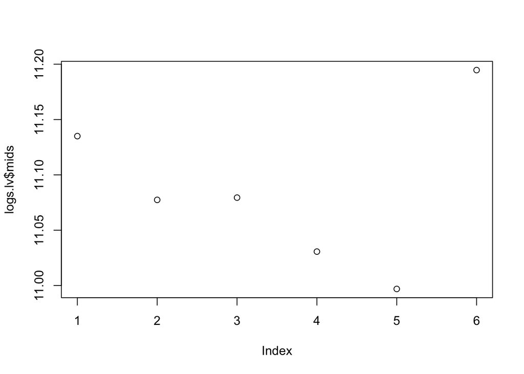

```r
plot(logs.lv$mids)
```

```r
#if take p = −1/2     -1/sqrt(lake$Area) Further investigation
recroots <- - 1 / sqrt(SalariesForSF$Total.benefits)
aplpack::stem.leaf(recroots)
```

```
## 1 | 2: represents 0.00012
##  leaf unit: 1e-05
##             n: 50
##    3    -48 | 720
##         -47 |
##    4    -46 | 4
##    6    -45 | 86
##         -44 |
##         -43 |
##   12    -42 | 774321
##   18    -41 | 988710
##   21    -40 | 751
##   22    -39 | 8
##   (4)   -38 | 4330
##   24    -37 | 94321110
##   16    -36 | 9988865330
##    6    -35 | 83
##    4    -34 | 877
## HI: -0.00281839201133087
```

```r
recroots.lv <- lval(recroots)
recroots.lv
```

```
##   depth           lo           hi         mids      spreads
## M  25.5 -0.003820052 -0.003820052 -0.003820052 0.0000000000
## H  13.0 -0.004194836 -0.003685002 -0.003939919 0.0005098336
## E   7.0 -0.004279353 -0.003604891 -0.003942122 0.0006744626
## D   4.0 -0.004646633 -0.003485888 -0.004066261 0.0011607454
## C   2.5 -0.004818170 -0.003477185 -0.004147678 0.0013409846
## B   1.0 -0.004877731 -0.002818392 -0.003848061 0.0020593388
```

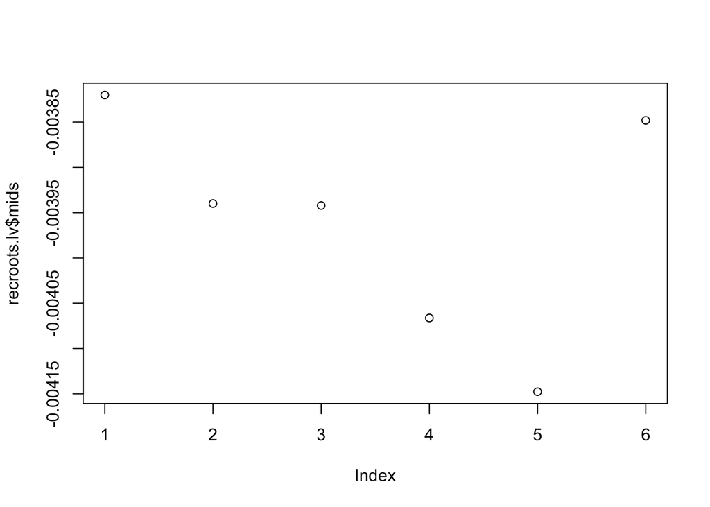

```r
plot(recroots.lv$mids)
```

```r
hinkley(roots)
```

```
##          h
## -0.1665895
```

```r
hinkley(logs)
```

```
##          h
## -0.2034287
```

```r
hinkley(recroots)
```

```
##          h
## -0.2396974
```

Looking at the values of d in Hinkley’s quick method, the correct reexpression appears to be grater than p=.5, although the value closest to 0 corresponds to the roots reexpression.

Therefore, we are gaoing to take a new power transforation as p=3

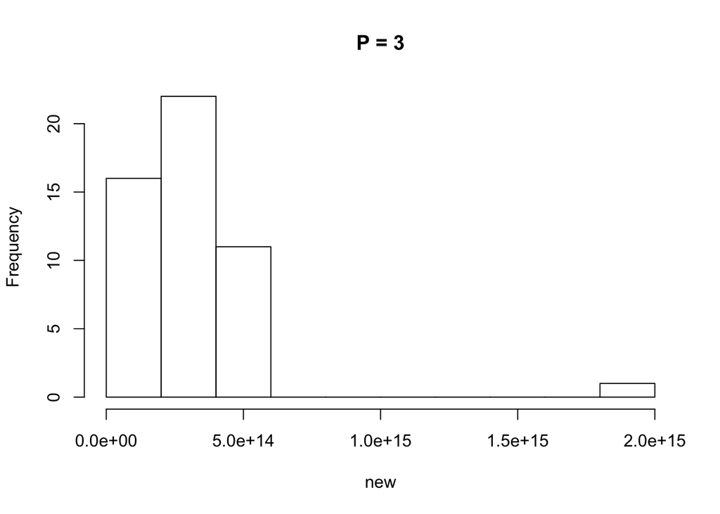

```r
new<-(SalariesForSF$Total.benefits) ^ 3
hist(new, main="P = 3")
```

```r
aplpack::stem.leaf(new)
```

```
## 1 | 2: represents 1.2e+14
##  leaf unit: 1e+13
##             n: 50
##    4    0. | 7789
##    6    1* | 00
##   16    1. | 6677778888
##   21    2* | 00123
##   22    2. | 5
##   (5)   3* | 01123
##   23    3. | 66788889999
##   12    4* | 01233
##    7    4. | 56
##    5    5* | 1
##    4    5. | 566
## HI: 1995223746235332
```

```r
new.lv <- lval(new)
new.lv
```

```
##   depth           lo           hi         mids      spreads
## M  25.5 3.218546e+14 3.218546e+14 3.218546e+14 0.000000e+00
## H  13.0 1.835314e+14 3.993683e+14 2.914498e+14 2.158369e+14
## E   7.0 1.628288e+14 4.556668e+14 3.092478e+14 2.928380e+14
## D   4.0 9.935037e+13 5.573390e+14 3.283447e+14 4.579886e+14
## C   2.5 7.993825e+13 5.657612e+14 3.228497e+14 4.858229e+14
## B   1.0 7.424942e+13 1.995224e+15 1.034737e+15 1.920974e+15
```

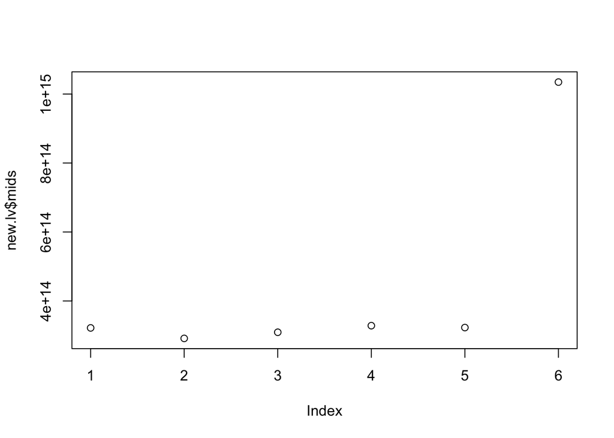

```r
plot(new.lv$mids)
```

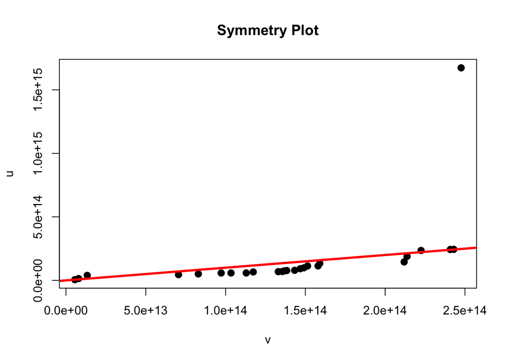

```r
symplot(new)
```

Now the date is reexpressed as roughly symmetric. However, there is one huge outlier so we have to be careful when we go to the further investigation.

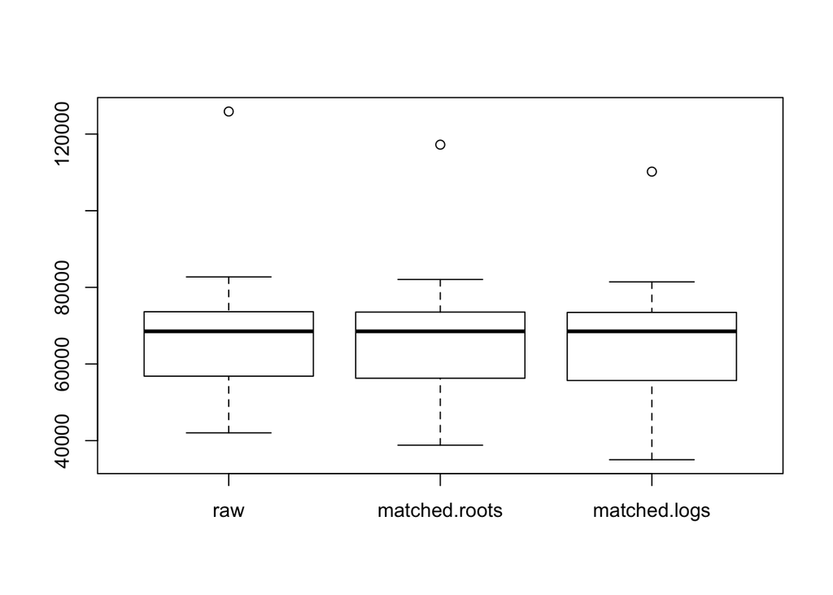

```r
#let x_0 = 65, the medain of the raw data
x_0<-68528.65
matched.roots <- x_0 + (sqrt(SalariesForSF$Total.benefits) - sqrt(x_0)) / (.5*x_0 ^ (-.5))
matched.logs <- x_0 + (log10(SalariesForSF$Total.benefits) - log10(x_0)) / (log10(exp(1)) / x_0)

raw <-SalariesForSF$Total.benefits
matched.roots <- mtrans(raw, 0.5)
matched.logs <- mtrans(raw, 0)
boxplot(data.frame(raw, matched.roots, matched.logs))
```

Now,all of data look like symmetric. While raw data has wider data spreads including outlier, matched.logs data has more narrow data spreads.

In conclusion, this transformation,(SalariesForSF$Total.benefits) ^ 3, gives the roughly symmetric distribution. However, it is not the best of the best because there is one huge outlier that gives the right-skewedness. We have met the data which is difficult to reexpress.